# Prognoza kursu USD-PLN na dzień 28.05.2019

Natalia Kiełbik, Joanna Kamińska, Justyna Kapucińska, Agnieszka Jadczak

22 maja 2019

# Wczytanie danych

Dane dotyczą kursu **USD-PLN** i zostały one pobrane w formacie `csv` ze [strony](https://stooq.pl/q/d/?s=usdpln).

Najpierw wczytamy dane, a następnie przygotujemy je do dalszej części analizy. W zadaniu tym bierzemy pod uwagę tylko jedną zmienną - **cenę zamknięcia**. Ostatni pomiar kursu zamknięcia pochodzi z dnia 21.05.2019r. W poniższej analizie postaramy się zadecydować czy w dniu 28.05.2019r. wymienimy pewną ilość USD, zakupioną dnia 21.05.2019r., na PLN.

## Wczytanie danych

```r
dane = read.csv2("usdpln_d.csv",header = FALSE, dec = ".")
```

## Utworzenie szeregu czasowego

```r
sc <- ts(dane, frequency = 1)
head(sc)
```

```
## Time Series:
## Start = 1
## End = 6
## Frequency = 1
##           V1
## [1,] 3.79090
## [2,] 3.76760
## [3,] 3.76007
## [4,] 3.74356
## [5,] 3.75583
## [6,] 3.72393
```

```r
length(sc)
```

```
## [1] 99
```

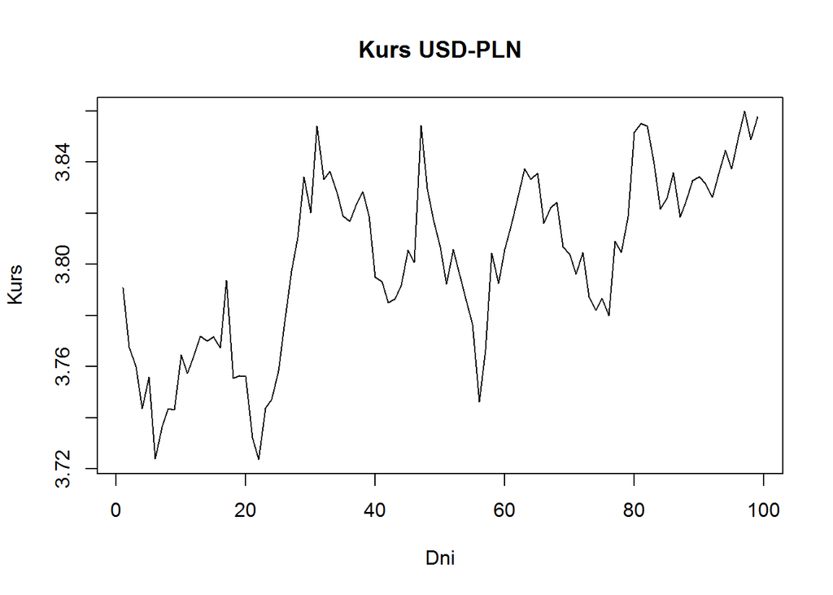

```r
plot(sc, main = "Kurs USD-PLN", ylab = "Kurs",xlab = "Dni")
```

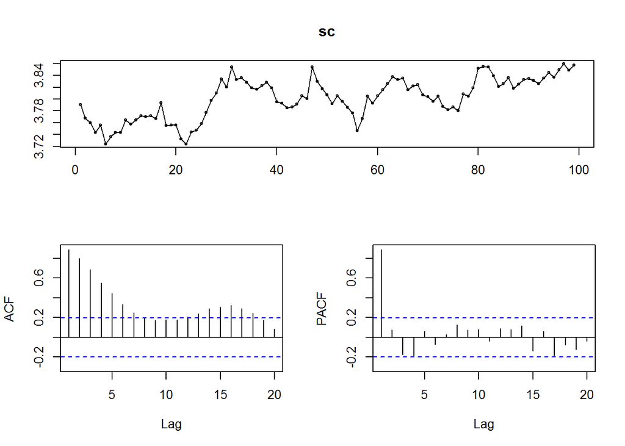

```r
tsdisplay(sc)
```

Sprawdźmy stacjonarność tego szeregu poprzez poniższy test statystyczny.

```r
adf.test(sc, alternative = "stationary")
```

```
##
##  Augmented Dickey-Fuller Test
##
## data:  sc
## Dickey-Fuller = -3.8895, Lag order = 4, p-value = 0.01746
## alternative hypothesis: stationary
```

Okazuje się, że wartśc p-value<0.05 zatem przyjmujemy hipotezę alternatywną, że badany szereg jest stacjonarny, tzn. nie mamy żadnej sezonowości ani trendów.

## Dopasowanie modelu

W celu stworzenia odpowiedniej prognozy, musimy na podstawie dostępnych danych dopasować odpowiedni model predykcyjny. Podzielimy dane na zbiór testowy i uczący oraz zbadamy modele AR, MA, ARMA i ARIMA. Na podstawie błędów średniokwadratowych wybierzemy odpowiedni model i na jego podstawie wygenerujemy prognozę na dzień 28.05.2019 r. oraz podejmiemy odpowiednią decyzję.

Parametry modeli predykcyjnych dla szeregu bez różnicowania

```r
p<-2
q<-14
d<-0
```

## Podział na zbiór uczący i testowy

```r
train<-window(sc, end= 90)
test<-window(sc,start=90)
```

## MODEL AR(p)

```r
AR<-arima(train, c(p,d,0))
summary(AR)
```

```
##
## Call:
## arima(x = train, order = c(p, d, 0))
##
## Coefficients:
##          ar1     ar2  intercept
##       0.8122  0.0761     3.7993
## s.e.  0.1051  0.1061     0.0135
##
## sigma^2 estimated as 0.0002418:  log likelihood = 246.28,  aic = -484.56
##
## Training set error measures:
##                       ME       RMSE        MAE         MPE      MAPE
## Training set 0.000165055 0.01555028 0.01198305 0.002600543 0.3155458
##                   MASE       ACF1
## Training set 0.9551413 0.02553174
```

## MODEL MA(q)

```r
MA<-arima(train, c(0,d,q))
summary(MA)
```

```
##
## Call:
## arima(x = train, order = c(0, d, q))
##
## Coefficients:
##          ma1     ma2     ma3     ma4     ma5     ma6     ma7     ma8
##       0.8683  0.9910  1.1584  0.7838  0.8560  0.7166  0.4874  0.2782
## s.e.  0.1137  0.1461  0.1856  0.2121  0.2318  0.2484  0.2574  0.2598
##          ma9    ma10    ma11    ma12     ma13    ma14  intercept
##       0.1245  0.2631  0.1165  0.0432  -0.1956  0.0245     3.7998
## s.e.  0.2644  0.2645  0.2382  0.1900   0.1418  0.1135     0.0101
##
## sigma^2 estimated as 0.0001744:  log likelihood = 257.31,  aic = -482.61
##
## Training set error measures:
##                         ME       RMSE        MAE          MPE      MAPE
## Training set -5.725569e-05 0.01320644 0.01028562 -0.002806062 0.2708822
##                   MASE        ACF1
## Training set 0.8198432 0.006542956
```

## MODEL ARMA

```r
ARMA<- arima(train, c(p,d,q))
summary(ARMA)
```

```
##
## Call:
## arima(x = train, order = c(p, d, q))
##
## Coefficients:
##          ar1     ar2     ma1     ma2     ma3      ma4      ma5      ma6
##       0.2289  0.7173  0.6639  0.0849  0.3024  -0.2074  -0.2056  -0.0362
## s.e.  0.6148  0.5502  0.6617  0.1574  0.1876   0.2110   0.2231   0.1590
##           ma7      ma8      ma9    ma10     ma11     ma12     ma13
##       -0.2610  -0.3417  -0.3025  0.0466  -0.0554  -0.2680  -0.3636
## s.e.   0.1385   0.1416   0.2132  0.1497   0.1389   0.2676   0.2168
##          ma14  intercept
##       -0.0564     3.8001
## s.e.   0.4058     0.0069
##
## sigma^2 estimated as 0.0001664:  log likelihood = 257.82,  aic = -479.64
##
## Training set error measures:
##                         ME       RMSE        MAE         MPE      MAPE
## Training set -0.0007128308 0.01289771 0.01012731 -0.01992992 0.2667456
##                   MASE        ACF1
## Training set 0.8072245 0.002175831
```

## MODEL ARIMA

```r
ARIMA<- auto.arima(train)
summary(ARIMA)
```

```
## Series: train
## ARIMA(0,1,0)
##
## sigma^2 estimated as 0.0002596:  log likelihood=241.15
## AIC=-480.3   AICc=-480.26   BIC=-477.81
##
## Training set error measures:
##                        ME       RMSE        MAE        MPE      MAPE
## Training set 0.0005243433 0.01602216 0.01244857 0.01287016 0.3278273
##                   MASE       ACF1
## Training set 0.9922463 -0.1350921
```

## Prognozy modelem AR

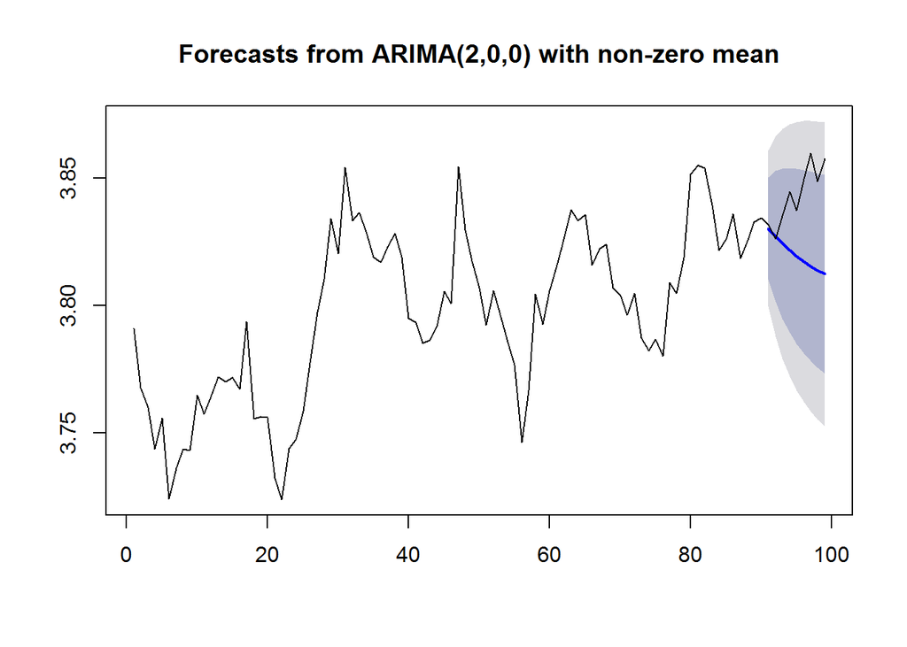

```r
prognozaAR<-forecast(AR,h=length(test)-1)
plot(prognozaAR,type="l")
lines(test)
```

## Prognozy modelem MA

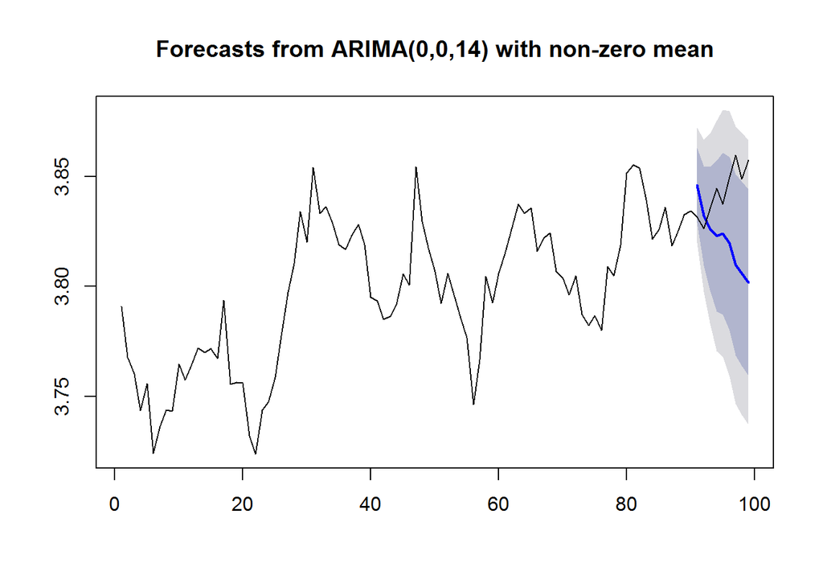

```r
prognozaMA<-forecast(MA,h=length(test)-1)
plot(prognozaMA,type="l")
lines(test)
```

## Prognozy modelem ARMA

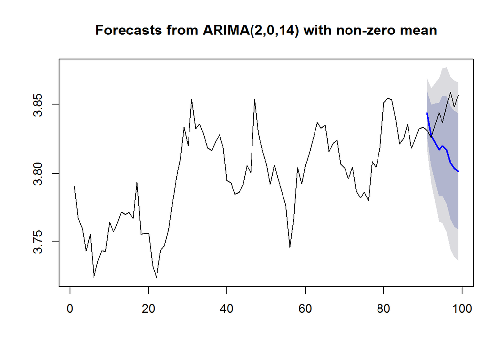

```r
prognozaARMA<-forecast(ARMA,h=length(test)-1)
plot(prognozaARMA,type="l")
lines(test)
```

## Prognoza modelem ARIMA

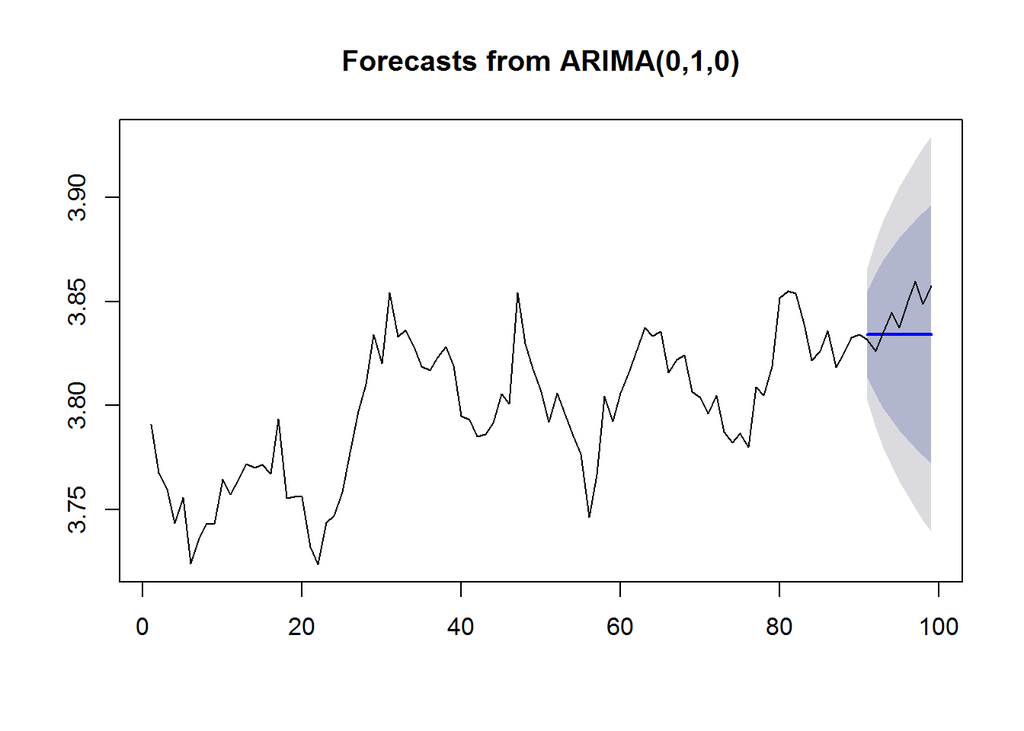

```r
prognozaARIMA<-forecast(ARIMA,h=length(test)-1)
plot(prognozaARIMA,type="l")
lines(test)
```

## BŁĘDY DLA ZAPROPONOWANYCH MODELI

Błędy średniokwadratowe dla zaproponowanych predykcji.

```r
m1<-mean( (prognozaAR$mean - test)^2, na.rm = TRUE)
m2<-mean( (prognozaMA$mean - test)^2, na.rm = TRUE)
m3<-mean( (prognozaARMA$mean - test)^2, na.rm = TRUE)

m4<-mean( (prognozaARIMA$mean - test)^2, na.rm = TRUE)
```

Błąd średniokwadratowy dla prognozy AR wynosi 8.09287810^{-4}, dla MA wynosi 0.0010408, natomiast dla ARMA wynosi 0.0011409, dla modelu ARIMA wynosi 2.038490210^{-4}.

```r
min(m1,m2,m3,m4)
```

```
## [1] 0.000203849
```

Najmniejszy błąd średniokwadratowy występuje przy użyciu modelu ARIMA. Dlatego do rozwiązania naszego problemu i wygenerowania prognozy na 28.05.2019r. użyjemy tego modelu.

## Prognoza na 28.05

Musimy stworzyć nowy zbiór uczący i testowy, a zatem:

```r
train1<-window(sc, end= 99)
```

```r
A<- auto.arima(train1)
summary(A)
```

```
## Series: train1
## ARIMA(0,1,0)
##
## sigma^2 estimated as 0.000243:  log likelihood=268.77
## AIC=-535.53   AICc=-535.49   BIC=-532.95
##
## Training set error measures:
##                        ME       RMSE        MAE       MPE      MAPE
## Training set 0.0007120293 0.01551077 0.01208597 0.0177953 0.3180223
##                   MASE       ACF1
## Training set 0.9930452 -0.1402204
```

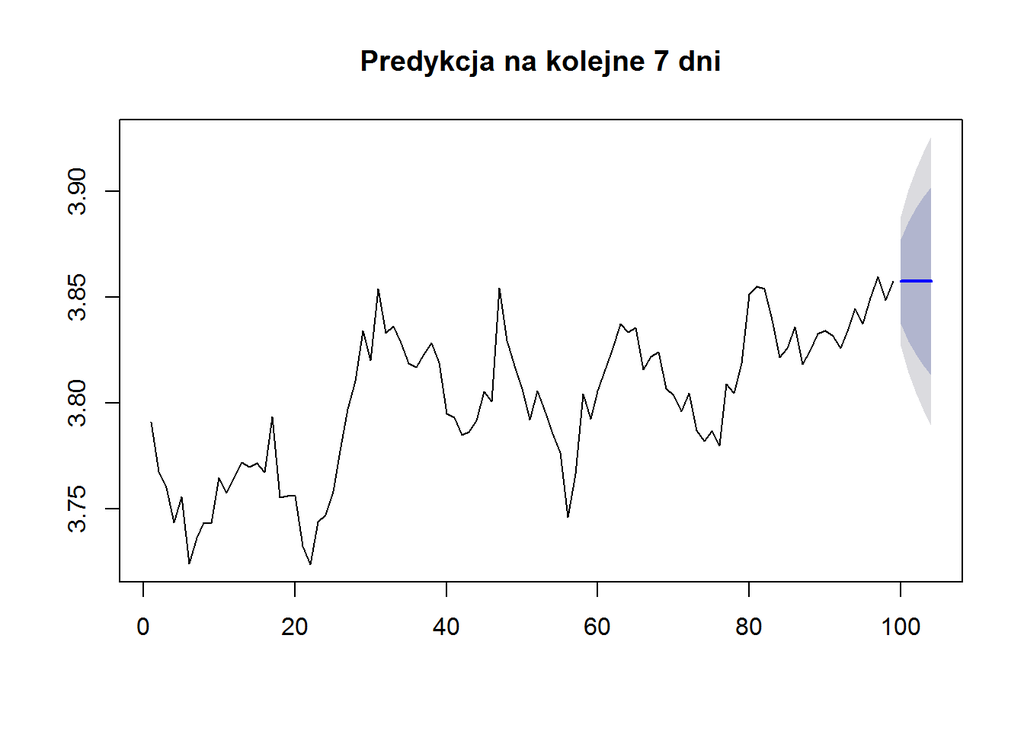

```r
prognoza<-forecast(A,h=5)
plot(prognoza,type="l", main="Predykcja na kolejne 7 dni")
```

```r
prognoza
```

```
##     Point Forecast    Lo 80    Hi 80    Lo 95    Hi 95
## 100         3.8576 3.837621 3.877579 3.827045 3.888155
## 101         3.8576 3.829345 3.885855 3.814388 3.900812
## 102         3.8576 3.822995 3.892205 3.804677 3.910523
## 103         3.8576 3.817642 3.897558 3.796489 3.918711
## 104         3.8576 3.812926 3.902274 3.789276 3.925924
```

```r
sc[99]
```

```
## [1] 3.8576
```

## DECYZJA

Ponieważ ostatnia wartość prognozy(28.05) jest równa wartości kursu dla 21.05, możemy przypuszczać, że kurs dolara będzie taki sam w dniu 28.05 w stosunku do 21.05. Wymiana USD na PLN nie przyniesie nam zysku.

## PODSUMOWANIE

Zgodnie ze [stroną](https://stooq.pl/q/d/?s=usdpln) cena zamknięcia w dniu 28.05 wynosiła 3.84812.

```r
cena2105<-sc[99]
predykcja<-3.8576
cena2805<-3.84812
```

Przewidywałysmy, że zysk z wymiany USD na PLN w dniu 28.05 wyniesie 0 na jednym USD, natomiast faktyczny zarobek z tej wymiany wyniósłby -0.00948 na każdym USD. Wymieniając USD na PLN poniosłybyśmy starty.